# Species distribution modeling R Workshop I

Ally Phillimore

### Introduction and Aims

Today’s workshop involves running and critiquing a species distribution model. In this first SDM session we will work with presence/absence data, and then in the second session we’ll move on to presence only data. One of the reasons for starting with presence/absence data is that we can use GLMs, which you will soon encounter on the **Statistics and Data Analysis** course. For anyone who is unsure of how they work please ask me in the session and I can go over it.

We’ll break down all the stages of species distribution modeling and do a lot of steps by hand so we get a clear idea of the logic.

This practical needs to start with a major acknowledgment in that most of it is a shortened version of an R practical written by an expert in the field Professor Damaris Zurell.

In this session we will cover the following steps that we discussed in the lectures:  
1. Conceptualisation  
2. Preparing data  
3. Model fitting  
4. Testing and critiquing the model  
5. Making projections in time

### Before we get started.

We will run the session today in R and R studio. Please ensure that you have a recent version of each on your computer. In R you will need to install the following packages.

geodata terra

To install a package and its dependencies:

```r
install.packages("geodata",dependencies=TRUE,repos="https://cloud.r-project.org")
```

And then to make the package available to you in R

```r
library(geodata)
library(terra)
```

I recommend saving your Rscript in an Rscipt file so that you can come back to it. Ideally you’d save your code on Github.

### 1. Conceptualisation

Before we even get started we need to think about the study species/population, the data we have, the modeling approach we will adopt and the climate variables that may be important. We also need to think about the question we will be asking. In this practical we are going to focus on an upland bird and ask how the area of suitable climate is likely to change in the future.

**Study species**  
Today we are going to work with a dataset on ring ouzel (*Turdus torquatus*). This is a summer migrant to European uplands and mountains. You can find out more about its ecology and where it is found in the UK from https://www.rspb.org.uk/birds-and-wildlife/wildlife-guides/bird-a-z/ring-ouzel/

If you want to see them, one or two pairs nest most years in the Pentland hills just outside Edinburgh.

**Study population**  
We’re going to work with a dataset on the presence/absence of this species in Switzerland. This dataset is based on a breeding bird atlas based on 3 visits a year to 1km grid cells from 1993-1996. These data were then used in Zurell et al. (2020) and made available to download from a data repository (https://datadryad.org/stash/dataset/doi:10.5061/dryad.k88v330). The dataset is available on Learn. Because our data come from a systematic survey we have information on absences as well as presences.

**Putative climatic drivers**  
One of the first questions we need to ask ourselves is what climate variables are likely to be important determinants of ring ouzel population size. If we aready know a lot about the ecology we can use that information to guide our choice of variables.

However, as I’m guessing none of us is expert in ring ouzel ecology what we’ll do is adopt the climatic variables that Zurell et al (2020) found to be most predictive. This isn’t really a strong justification if we were doing this analysis thoroughly, but it;s useful here as it should give us some fairly strong relationships between climate variables and presence/absence. We will focus on bio5 = maximum temperature of the warmest month, bio2 = mean diurnal range, bio14 = precipitation of driest month (all from https://www.worldclim.org/data/bioclim.html)

**Question 1: You will be analysing presence/absence data using a generalized linear model (GLM), what distribution family should you choose?**

*A GLM with binomial family errors should work well. A binary outcome is a special case of a binomial model.*

Questions we should ask ourselves during the conceptualisation stage  
- What biases may our dataset have?  
- Do we expect our species to be at equilibrium with climate during the survey period?  
- What impact do we expect each of our climate variables to have on our species and why? Are these effects of climate likely to be direct or indirect via impacts on resources?

### 2. Data preparation

Now we can get started. First download the ring ouzel and climate data from Learn and save it on your computer. Then we’re going to import the dataset (note that you will need to change the file path to match where you saved the Data_SwissBreedingBirds file).

```r
avi_dat <- read.table('~/Dropbox/teaching/MSC/1_biodiversityunderpressure/SDMs/practicals/Data_SwissBreedingBirds.csv', header=T, sep=',')
```

**Click to expand R code and output**

```r
  # Your R code here
nrow(avi_dat)
```

```
## [1] 2535
```

```r
summary(avi_dat)
```

```
##  Falco_subbuteo   Anthus_trivialis Phylloscopus_bonelli Tetrao_tetrix
##  Min.   :0.0000   Min.   :0.0000   Min.   :0.0000       Min.   :0.0000
##  1st Qu.:0.0000   1st Qu.:0.0000   1st Qu.:0.0000       1st Qu.:0.0000
##  Median :0.0000   Median :0.0000   Median :0.0000       Median :0.0000
##  Mean   :0.1057   Mean   :0.3483   Mean   :0.2162       Mean   :0.1278
##  3rd Qu.:0.0000   3rd Qu.:1.0000   3rd Qu.:0.0000       3rd Qu.:0.0000
##  Max.   :1.0000   Max.   :1.0000   Max.   :1.0000       Max.   :1.0000
##
##  Parus_caeruleus  Dendrocopos_major Garrulus_glandarius Carduelis_spinus
##  Min.   :0.0000   Min.   :0.000     Min.   :0.0000      Min.   :0.000
##  1st Qu.:0.0000   1st Qu.:0.000     1st Qu.:0.0000      1st Qu.:0.000
##  Median :1.0000   Median :1.000     Median :1.0000      Median :0.000
##  Mean   :0.6331   Mean   :0.697     Mean   :0.7199      Mean   :0.129
##  3rd Qu.:1.0000   3rd Qu.:1.000     3rd Qu.:1.0000      3rd Qu.:0.000
##  Max.   :1.0000   Max.   :1.000     Max.   :1.0000      Max.   :1.000
##
##  Loxia_curvirostra Phylloscopus_trochilus Certhia_brachydactyla  Sylvia_borin
##  Min.   :0.000     Min.   :0.0000         Min.   :0.0000        Min.   :0.000
##  1st Qu.:0.000     1st Qu.:0.0000         1st Qu.:0.0000        1st Qu.:0.000
##  Median :0.000     Median :0.0000         Median :0.0000        Median :1.000
##  Mean   :0.243     Mean   :0.1606         Mean   :0.4032        Mean   :0.611
##  3rd Qu.:0.000     3rd Qu.:0.0000         3rd Qu.:1.0000        3rd Qu.:1.000
##  Max.   :1.000     Max.   :1.0000         Max.   :1.0000        Max.   :1.000
##
##  Phoenicurus_phoenicurus Hippolais_icterina Pyrrhula_pyrrhula
##  Min.   :0.0000          Min.   :0.0000     Min.   :0.0000
##  1st Qu.:0.0000          1st Qu.:0.0000     1st Qu.:0.0000
##  Median :0.0000          Median :0.0000     Median :0.0000
##  Mean   :0.2229          Mean   :0.0284     Mean   :0.4671
##  3rd Qu.:0.0000          3rd Qu.:0.0000     3rd Qu.:1.0000
##  Max.   :1.0000          Max.   :1.0000     Max.   :1.0000
##
##  Emberiza_citrinella Muscicapa_striata  Picus_canus      Picus_viridis
##  Min.   :0.0000      Min.   :0.0000    Min.   :0.00000   Min.   :0.0000
##  1st Qu.:0.0000      1st Qu.:0.0000    1st Qu.:0.00000   1st Qu.:0.0000
##  Median :0.0000      Median :1.0000    Median :0.00000   Median :1.0000
##  Mean   :0.4619      Mean   :0.5061    Mean   :0.08481   Mean   :0.5037
##  3rd Qu.:1.0000      3rd Qu.:1.0000    3rd Qu.:0.00000   3rd Qu.:1.0000
##  Max.   :1.0000      Max.   :1.0000    Max.   :1.00000   Max.   :1.0000
##
```

[output cut: 169 more lines]

```
##  Min.   :0.1203         Min.   :   60   Min.   :  320      Min.   :   80
##  1st Qu.:0.3957         1st Qu.: 7500   1st Qu.:11520      1st Qu.: 8540
##  Median :0.4804         Median :10760   Median :15840      Median :12260
##  Mean   :0.4743         Mean   :10895   Mean   :16091      Mean   :12227
##  3rd Qu.:0.5552         3rd Qu.:14040   3rd Qu.:20520      3rd Qu.:15920
##  Max.   :0.8972         Max.   :33740   Max.   :36160      Max.   :33420
##
##     TE_total      data_type          blockCV_tile
##  Min.   :  800   Length:2535        Min.   :1.000
##  1st Qu.:30000   Class :character   1st Qu.:2.000
##  Median :39720   Mode  :character   Median :4.000
##  Mean   :39212                      Mean   :3.289
##  3rd Qu.:48320                      3rd Qu.:4.000
##  Max.   :80960                      Max.   :5.000
##                                     NA's   :761
```

This dataset contains data on 56 bird species across 2535 grid cells. It doesn’t include spatial information (latitudes and longitudes), probably because some of this information is sensitive. But for our purposes today, this doesn’t matter as locations have already been matched with climate data from worldclim.  
Looking at the data summary above, familiarise yourself with the column names. What proportion of grid cells are ring ouzels found in?  
You will notice a column with the header blockCVtile - this divides Switzerland into 5 regions and we will use it later for spatial cross validation.

Next we will subset the data to select just the columns that we’ll be working with.

```r
ouzel_cols <- c('Turdus_torquatus', 'bio_5', 'bio_2', 'bio_14', 'blockCV_tile')

ouzel_df <- data.frame(avi_dat)[ouzel_cols]

summary(ouzel_df)
```

```
##  Turdus_torquatus     bio_5           bio_2            bio_14
##  Min.   :0.0000   Min.   :12.23   Min.   : 5.592   Min.   : 24.00
##  1st Qu.:0.0000   1st Qu.:18.81   1st Qu.: 7.789   1st Qu.: 64.00
##  Median :0.0000   Median :22.39   Median : 8.293   Median : 75.00
##  Mean   :0.2548   Mean   :21.42   Mean   : 8.243   Mean   : 80.97
##  3rd Qu.:1.0000   3rd Qu.:24.29   3rd Qu.: 8.689   3rd Qu.: 95.50
##  Max.   :1.0000   Max.   :28.27   Max.   :11.471   Max.   :177.00
##
##   blockCV_tile
##  Min.   :1.000
##  1st Qu.:2.000
##  Median :4.000
##  Mean   :3.289
##  3rd Qu.:4.000
##  Max.   :5.000
##  NA's   :761
```

Next we need to import current and future climate data for Switzerland and clip it to the extent of Switzerland. We can download and import the same climate variables in directly from WORLDCLIM This next bit of code relies on the geodata package.

You will need to enter your working directory for the output_dir below.

```r
output_dir<-"~/Dropbox/teaching/MSC/1_biodiversityunderpressure/SDMs/practicals/practical1_climdata"

bio_curr <-worldclim_country("Switzerland",version="2.1", var='bio', res=10, lon=5.5, lat=45.5, path=output_dir)[[c(2,5,14)]]

bio_fut <- cmip6_world(var = "bio", model = "CNRM-CM6-1-HR", ssp = "245", res = 10,  time = "2041-2060",  lon = c(5.96, 10.49),  lat = c(45.82, 47.81),path=output_dir)[[c(2,5,14)]]
```

There is a risk that the wifi in this room is not capable of downloading these files. In case of that eventuality we have a plan B of accessing the required climate files from Ally’s external drive.

For the future climate we can see (directly above) from the code that we’ve requested an SSP == 2, RCP=4.5 pathway and for the period 2040-2060. The climate projections come from the CMIP6 (Coupled Model Intercomparison Project Phase 6) dataset. The The resolution of grid cells is at 10 minutes, which in Switzerland is approx 12km. We’ve used this global model (“CNRM-CM6-1-HR”), which is supposed to be quite well downscaled for Europe (in other words the global climate models are run at a coarser resolution and then models can be used to make the downscaled data a better fit to the landscape elevation etc), but there are a wide variety of different models we could choose from if we wanted to do ensemble forecasting.

Our next step is to reproject the raster data in Swiss coordinates and first crop the layers for the Swiss boundary. In the interest of time, I suggest we just copy and paste this code rather than looking in details at how it works.

```r
# A spatial mask of Switzerland in Swiss coordinates
bg <- rast('/vsicurl/https://damariszurell.github.io/SDM-Intro/CH_mask.tif')

bio_curr <- terra::project(bio_curr, bg)
bio_fut <- terra::project(bio_fut, bg)
#we need to change the projection of our cliamte data to match that of the bg file.

bio_curr <- terra::resample(bio_curr, bg)
bio_fut <- terra::resample(bio_fut, bg)
#we then need to make the resolution equivalent to bg.


bio_curr <- terra::mask(bio_curr, bg)
bio_fut <- terra::mask(bio_fut, bg)
#we then need to clip the extent to match an outline of Switzerland

names(bio_curr) <- c('bio_2', 'bio_5', 'bio_14')
names(bio_fut) <- c('bio_2', 'bio_5', 'bio_14')
```

Next we’ll plot the current climate variables and how they are projected to change over time. Reminder bio5 = maximum temperature of the warmest month, bio2 = mean diurnal range, bio14 = precipitation of driest month

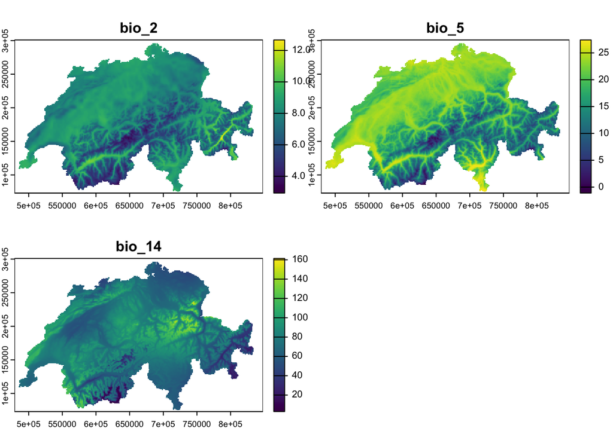

```r
plot(bio_curr)
```

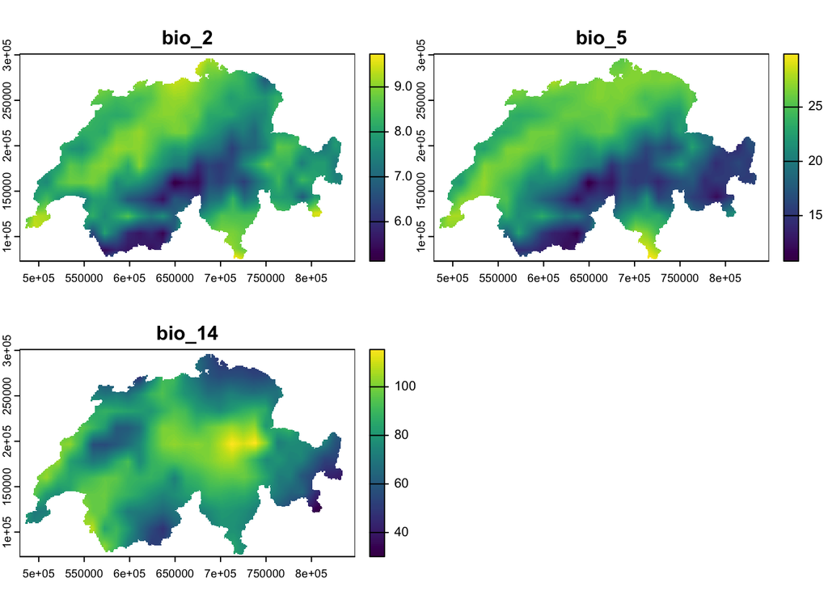

```r
plot(bio_fut)
```

Questions we should ask ourselves with the climate data  
- Do the values for climate variables in the maps look plausible?  
- What are the likely spatial drivers of variation in these metrics?  
- How much are these metrics changing over time (i.e. between the current and future)?  
- Is the climate data at the correct resolution to be important to the focal species?

### 3. Model fitting

This is where the fun starts!

Here’s a challenge for you. Can you code a binomial GLM with all three predictors fitted as linear and squared terms? There is code below, but try to do this yourself first.

**Only open when you’ve had a go**

```r
model <- glm( Turdus_torquatus ~ bio_2 + I(bio_2^2) + bio_5 + I(bio_5^2) + bio_14 + I(bio_14^2), family='binomial', data=ouzel_df)

summary(model)
```

```
##
## Call:
## glm(formula = Turdus_torquatus ~ bio_2 + I(bio_2^2) + bio_5 +
##     I(bio_5^2) + bio_14 + I(bio_14^2), family = "binomial", data = ouzel_df)
##
## Coefficients:
##               Estimate Std. Error z value Pr(>|z|)
## (Intercept) -5.139e+01  7.232e+00  -7.106 1.20e-12 ***
## bio_2        1.064e+00  1.648e+00   0.645  0.51862
## I(bio_2^2)  -1.255e-02  1.021e-01  -0.123  0.90219
## bio_5        5.191e+00  5.304e-01   9.786  < 2e-16 ***
## I(bio_5^2)  -1.650e-01  1.496e-02 -11.032  < 2e-16 ***
## bio_14       8.625e-02  1.830e-02   4.714 2.42e-06 ***
## I(bio_14^2) -3.079e-04  9.349e-05  -3.293  0.00099 ***
## ---
## Signif. codes:  0 '***' 0.001 '**' 0.01 '*' 0.05 '.' 0.1 ' ' 1
##
## (Dispersion parameter for binomial family taken to be 1)
##
##     Null deviance: 2877.6  on 2534  degrees of freedom
## Residual deviance: 1101.6  on 2528  degrees of freedom
## AIC: 1115.6
##
## Number of Fisher Scoring iterations: 8
```

**Question 2: From the model summary, which variables look to be having an important effect?**

### 4. Testing and critiquing our model

#### 4.1 Partial effects

The first step of model critique is to understand how each climate variable affects the presence/absence of ring ouzels. To do this we will plot the partial effects, i.e. the effects of each variable whilst holding the other variables constant.

We will achieve this by using the predict function for each variable. In order to use the predict function we will generate a new data frame in which our focal variable varies but the other variables are held constant.

Starting with bio_2

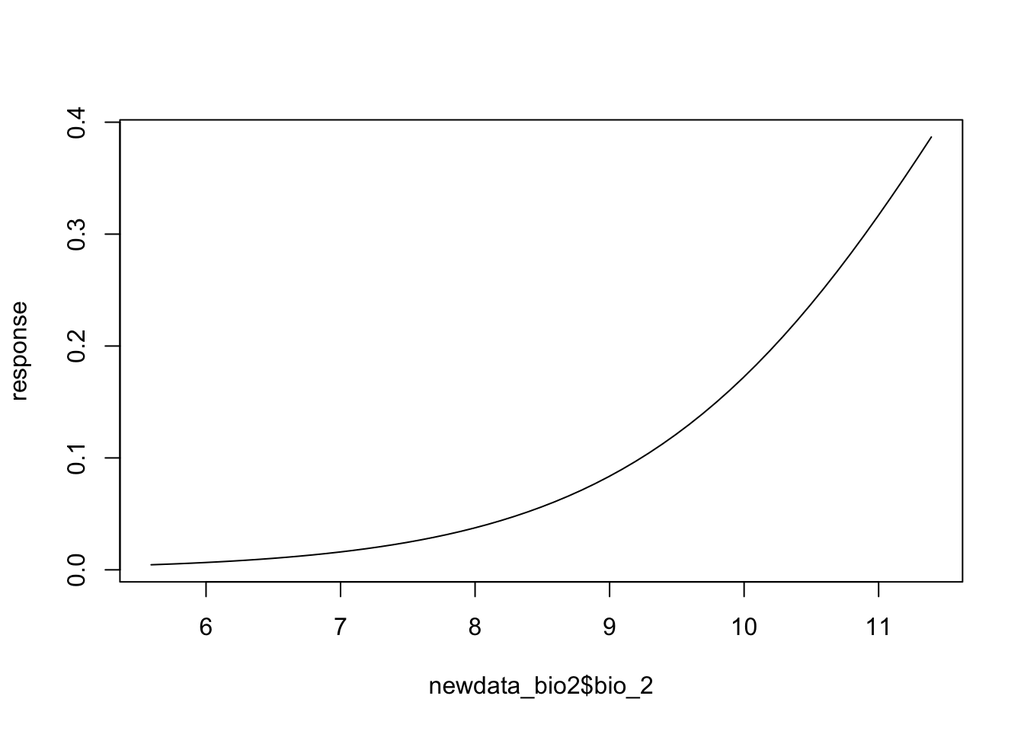

```r
bio_2<-seq(min(ouzel_df$bio_2),max(ouzel_df$bio_2),0.1)

newdata_bio2<-expand.grid(bio_2,mean(ouzel_df$bio_5),mean(ouzel_df$bio_14))
names(newdata_bio2)<-c("bio_2","bio_5","bio_14")
#To use predict we need to generate a new dataset. We will set the other two climate variables at their mean.

response<-predict(model,newdata=newdata_bio2,type="response")
#We've told the predict function to make a prediction on the response scale, ie. in terms of presence/absence

plot(newdata_bio2$bio_2,response,type="l")
```

Once you’ve done that, try to amend the code above to look at the predicted relationship for bio_5 and bio_14.

**Question 3: Which of the relationships is humped?**

*Hopefully you found humped relationships for bio_5 and bio_14*

#### 4.2 Spatial cross validation

Now we’re going to conduct spatial cross validation to examine how well our model can predict the presence/absence of ring ouzels in different blocks (see Fig 1). If you remmeber back to the lecture, this involves a few steps. (1) we randomly drop a block from the dataset. (2) We then refit the glm to this reduced “training” dataset. (3) Use the climate data in the ring ouzel dataset to obtain a predicted probability of ring ouzel presence. (4) Consider different probability thresholds to generate a ROC curve. (5) Calculate the area under the curve. And then repeat for each of the blocks.

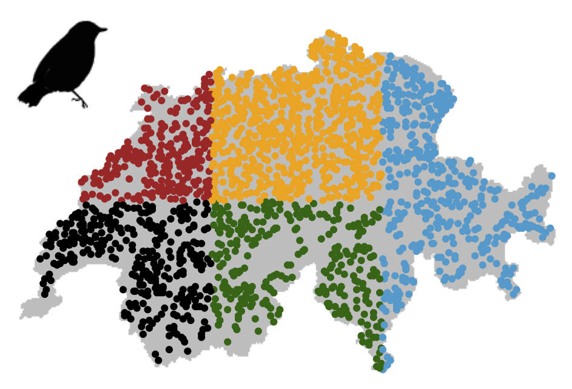

In our case there are only 5 spatial blocks, so we will run the cross validation five times and calculate the AUC each time. From these five blocks we can then calculate an average AUC. You can find R functions to do all of this, but today we’ll do all the steps ourselves to make sure we understand the process.

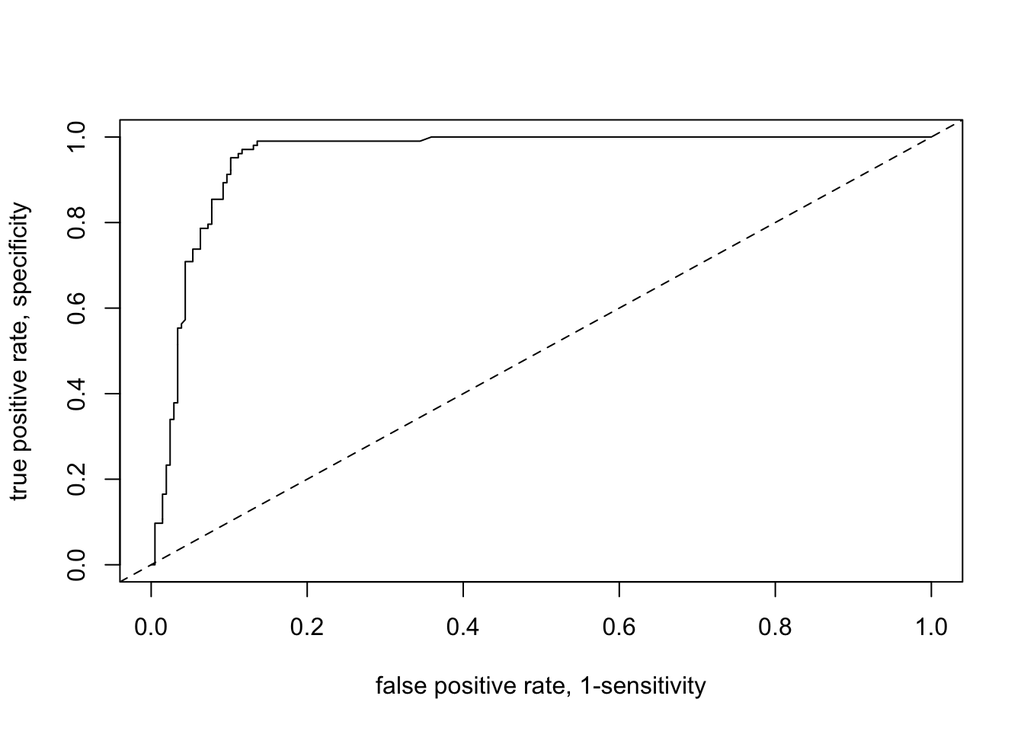

```r
#first we will exclude spatial block 1.
training1<-subset(ouzel_df,blockCV_tile!=1)
#next we re-run the glm
model1<-glm( Turdus_torquatus ~ bio_2 + I(bio_2^2) + bio_5 + I(bio_5^2) + bio_14 + I(bio_14^2), family='binomial', data=training1)
#we will then subset the data for a testing dataset and we will see how well the glm fitted to the other data does in predicting presences in this testing block
testing<-subset(ouzel_df,blockCV_tile==1)
predicted<-predict(model1,testing,type="response")
#so here we have a prediction as a proportion rather than as a pres/abs.

#The next step is to take different threshold values (i.e probability values at which we count a species as present or absent)
thresholds<-seq(0,1,0.001)
tpr<-c()
fpr<-c()
#We will then use a loop to consider the true positive and false positive rate at each threshold value
for(x in 1:length(thresholds)){

predicted.pres<-as.numeric(predicted>thresholds[x])

present_correct<-length(which(predicted.pres*testing$Turdus_torquatus==1))
present_incorrect<-length(which(testing$Turdus_torquatus-predicted.pres==1))
tpr[x]<-present_correct/(present_correct+present_incorrect)

absent_correct<-length(which(predicted.pres+testing$Turdus_torquatus==0))
absent_incorrect<-length(which(testing$Turdus_torquatus-predicted.pres==-1))
fpr[x]<-absent_incorrect/(absent_incorrect+absent_correct)

}

#When we've run that we can plot the receiver operating characteristic (ROC) curve
plot(fpr,tpr,xlab="false positive rate, 1-sensitivity",ylab="true positive rate, specificity",type="l")
abline(0,1,lty=2)
```

```r
#Finally to calculate AUC, we can imagine lots of small rectangles. For each one we will calculate its areas and then the area under curve is the sum of those

sortedvals<-cbind(fpr,tpr)[order(fpr),]

AUC<-0
for(x in 2:length(sortedvals[,1])){
  AUC<-AUC+(sortedvals[x,1]-sortedvals[x-1,1])*sortedvals[x-1,2]}

AUC
```

```
##       fpr
## 0.9477802
```

This is quite a high AUC value, suggesting a good model performance when it comes to predicting ring ouzel presence/absence in another region. You could now repeat this process for the other blocks to calculate an average AUC (only if you want to).

We also want to decide on an optimal probability threshold, as we’ll use this for the mapping stage that comes next. Below is one way of doing this

```r
#Here we'll find a value that maximises true positive rate and minimises false positive rate
bestthreshold<-thresholds[which.max(tpr+(1-fpr))]

bestthreshold
```

```
## [1] 0.117
```

**Question 4: Which would be better for spatial validation, dividing grid cells into training and testing at random or dividing grid cells into spatial blocks?**

*Dividing grid cells into spatial blocks is better as then we are making predictions to a dataset that represents more of an extrapolation rather than interpolation.*

### 5. Prediction

OK, we’ve convinced ourselves that the model is performing quite well. The final step is to predict where might be suitable for ring ouzels now and in the future.

The four ingredients that we needs are (i) the model, (ii) the climate layers that we imported from worldclim and (iii) the predict function that we’ve already used and (iv) the threshold we identified.

We’ll start with the current distribution.

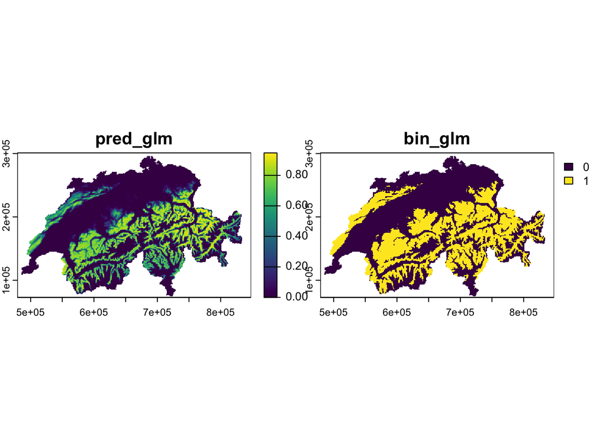

```r
bio_curr_df <- as.data.frame(bio_curr, xy = TRUE, na.rm = FALSE)

bio_curr_df$pred_glm<-predict(model,bio_curr_df,type="response")

# Make binary predictions:
bio_curr_df$bin_glm <- ifelse(bio_curr_df$pred_glm > bestthreshold, 1, 0)

#plot the current probability and predicted presence/absence.


r_pred_curr <- rast(as.matrix(bio_curr_df[,-c(3:5)]),type="xyz")
plot(r_pred_curr)
```

Unfortunately we’re not able to check how this predicted distribution compares with the raw data as there were no spatial coordinates in the raw data. However, we can check whether it matches with other maps of the distribution of ring ouzels in Switzerland, e.g., https://www.vogelwarte.ch/en/birds/birds-of-switzerland/ring-ouzel

The next step is to plot the future distribution of ring ouzels. If you can try to amend the code above to do this.

**If you get stuck, the code is here**

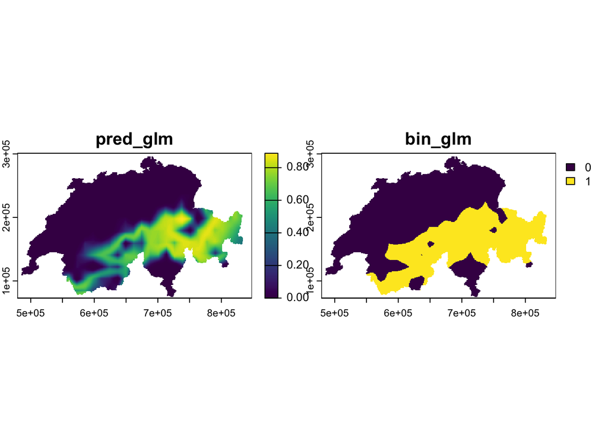

```r
bio_fut_df <- as.data.frame(bio_fut, xy = TRUE, na.rm = FALSE)

bio_fut_df$pred_glm<-predict(model,bio_fut_df,type="response")

# Make binary predictions:
bio_fut_df$bin_glm <- ifelse(bio_fut_df$pred_glm > bestthreshold, 1, 0)

#plot the current probability and predicted presence/absence.

r_pred_fut <- rast(as.matrix(bio_fut_df[,-c(3:5)]),type="xyz")
plot(r_pred_fut)
```

What does this tell us about predicted changes to the area of suitable climate for ring ouzels in Switzerland?

### Finally, if you really want to do more

Really well done, we’ve already covered a huge amount today.

If you have finished this with time to spare you could try running models for a different Swiss bird species, and this would require that you test a series of cliamte predictors to identify the best one.

If in the future you are interested to go into more detail on this topic then I highly recommend reading the more extensive practical that this practical draws on. Note that Zurell’s practical also includes code to run a random forests model to identify the effects of climate: https://damariszurell.github.io/SDM-Intro/

If you want to explore correlative SDMs further there are excellent resources online. Other practicals by Damaris Zurell are very clear:  
https://damariszurell.github.io/EEC-MGC/index.html  
As are these by Hijmans and Elith: https://rspatial.org/raster/sdm/index.html

### References

Zurell, Damaris, Niklaus E. Zimmermann, Helge Gross, Andri Baltensweiler, Thomas Sattler, and Rafael O. Wüest. 2020. “Testing Species Assemblage Predictions from Stacked and Joint Species Distribution Models.” Journal of Biogeography 47 (1): 101–13. https://doi.org/10.1111/jbi.13608.